# Bootstrap for sampling distribution of sample mean

## Assessing assumptions

- Our $t$-tests assume normality of variable being tested
- but, Central Limit Theorem says that normality matters less if sample is “large”
- in practice “approximate normality” is enough, but how do we assess whether what we have is normal enough?
- so far, use histogram/boxplot and make a call, allowing for sample size.

## What actually has to be normal

- is: **sampling distribution of sample mean**
- the distribution of sample mean over *all possible samples*
- but we only have *one* sample!
- Idea: assume our sample is representative of the population, and draw samples from our sample (!), with replacement.
- This gives an idea of what different samples from the population might look like.
- Called *bootstrap*, after expression “to pull yourself up by your own bootstraps”.

## Packages

```r
library(tidyverse)
```

## Blue Jays attendances

```r
jays$attendance
```

```
 [1] 48414 17264 15086 14433 21397 34743 44794 14184 15606
[10] 18581 19217 21519 21312 30430 42917 42419 29306 15062
[19] 16402 19014 21195 33086 37929 15168 17276
```

- A bootstrap sample:

```r
s <- sample(jays$attendance, replace = TRUE)
s
```

```
 [1] 21195 34743 21312 44794 16402 19014 34743 21195 17264
[10] 18581 19014 19217 34743 19217 14433 15062 16402 15062
[19] 34743 15062 15086 15168 15086 48414 30430
```

## Sorting

- It is easier to see what is happening if we sort both the actual attendances and the bootstrap sample:

```r
sort(jays$attendance)
```

```
 [1] 14184 14433 15062 15086 15168 15606 16402 17264 17276
[10] 18581 19014 19217 21195 21312 21397 21519 29306 30430
[19] 33086 34743 37929 42419 42917 44794 48414
```

```r
sort(s)
```

```
 [1] 14433 15062 15062 15062 15086 15086 15168 16402 16402
[10] 17264 18581 19014 19014 19217 19217 21195 21195 21312
[19] 30430 34743 34743 34743 34743 44794 48414
```

## Getting mean of bootstrap sample

- A bootstrap sample is same size as original, but contains repeated values (eg. 15062) and missing ones (42917).
- We need the mean of our bootstrap sample:

```r
mean(s)
```

```
[1] 23055.28
```

- This is a little different from the mean of our actual sample:

```r
mean(jays$attendance)
```

```
[1] 25070.16
```

- Want a sense of how the sample mean might vary, if we were able to take repeated samples from our population.
- Idea: take lots of *bootstrap* samples, and see how *their* sample means vary.

## Setting up bootstrap sampling

- Begin by setting up a dataframe that contains a row for each bootstrap sample. I usually call this column `sim`. Do just 4 to get the idea:

```r
tibble(sim = 1:4)
```

| sim |
| --- |
| 1 |
| 2 |
| 3 |
| 4 |

## Drawing the bootstrap samples

- Then set up to work one row at a time, and draw a bootstrap sample of the attendances in each row:

```r
tibble(sim = 1:4) %>%
  rowwise() %>%
  mutate(sample = list(sample(jays$attendance,
                              replace = TRUE)))
```

| sim | sample |
| --- | --- |
| 1 |  |
| 2 |  |
| 3 |  |
| 4 |  |

- Each row of our dataframe contains *all* of a bootstrap sample of 25 observations drawn with replacement from the attendances.

## Sample means

- Find the mean of each sample:

```r
tibble(sim = 1:4) %>%
  rowwise() %>%
  mutate(sample = list(sample(jays$attendance,
                              replace = TRUE))) %>%
  mutate(my_mean = mean(sample))
```

| sim | sample | my_mean |
| --- | --- | --- |
| 1 |  | 28472.20 |
| 2 |  | 28647.52 |
| 3 |  | 23328.88 |
| 4 |  | 24808.20 |

- These are (four simulated values of) the bootstrapped sampling distribution of the sample mean.

## Make a normal quantile plot of them

- rather pointless here, but to get the idea:

```r
tibble(sim = 1:4) %>%
  rowwise() %>%
  mutate(sample = list(sample(jays$attendance, replace = TRUE))) %>%
  mutate(my_mean = mean(sample)) %>%
  ggplot(aes(sample = my_mean)) +
    stat_qq() + stat_qq_line() -> g
```

## The (pointless) plot

```r
g
```

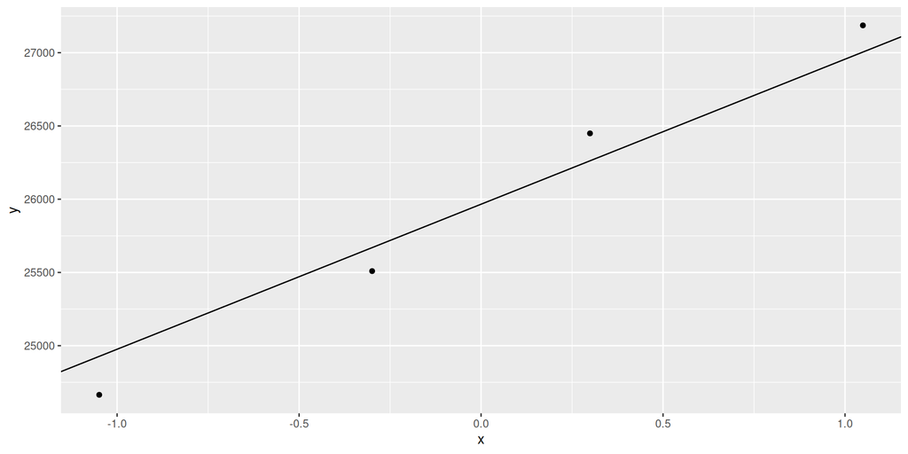

## Now do again with a decent number of bootstrap samples

- say 10000, to get a good look at the tails:

```r
tibble(sim = 1:10000) %>%
  rowwise() %>%
  mutate(sample = list(sample(jays$attendance,
                              replace = TRUE))) %>%
  mutate(my_mean = mean(sample)) %>%
  ggplot(aes(sample = my_mean)) +
    stat_qq() + stat_qq_line() -> g
```

## The (better) plot

```r
g
```

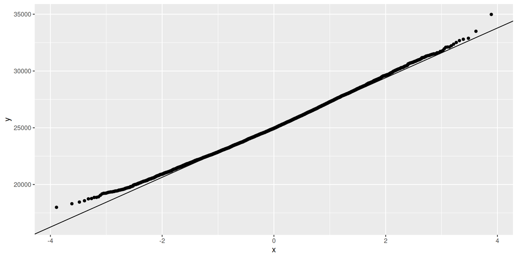

## Comments

- This is very close to normal (only very slightly right-skewed)
- The bootstrap says that the sampling distribution of the sample mean is close to normal, even though the distribution of the data is not
- A sample size of 25 is big enough to overcome the skewness that we saw
- This is the Central Limit Theorem in practice
- It is surprisingly powerful.
- Thus, the $t$-test is actually perfectly good here.

## Comments on the code 1/2

- You might have been wondering about this:

```r
tibble(sim = 1:4) %>%
  rowwise() %>%
  mutate(sample = list(sample(jays$attendance,
                              replace = TRUE)))
```

| sim | sample |
| --- | --- |
| 1 |  |
| 2 |  |
| 3 |  |
| 4 |  |

## Comments on the code 2/2

- how did we squeeze all 25 sample values into one cell?
  - sample is a so-called “list-column” that can contain anything.
- why did we have to put `list()` around the `sample()`?
  - because `sample` produces a collection of numbers, not just a single one
  - the `list()` signals this: “make a list-column of samples”.

## Two samples

- Assumption: *both* samples are from a normal distribution.
- In this case, each sample should be “normal enough” given its sample size, since Central Limit Theorem will help.
- Use bootstrap on each group independently, as above.

## Kids learning to read

| group | score |
| --- | --- |
| t | 24 |
| t | 61 |
| t | 59 |
| t | 46 |
| t | 43 |
| t | 44 |
| t | 52 |
| t | 43 |
| t | 58 |
| t | 67 |

[output cut: 34 more lines]

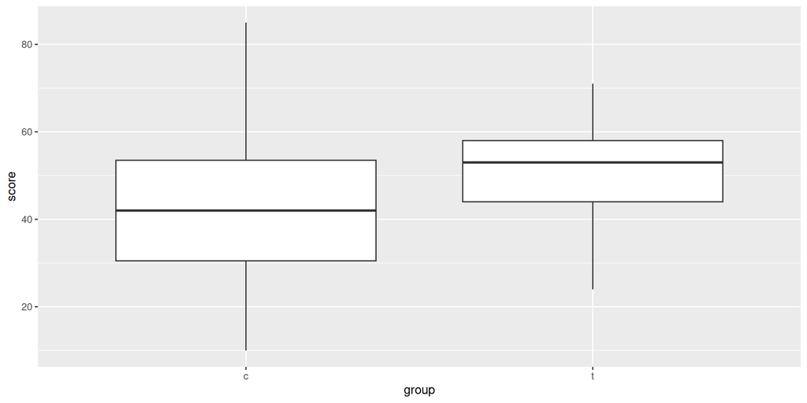

```r
ggplot(kids, aes(x=group, y=score)) + geom_boxplot()
```

## or, a normal quantile plot

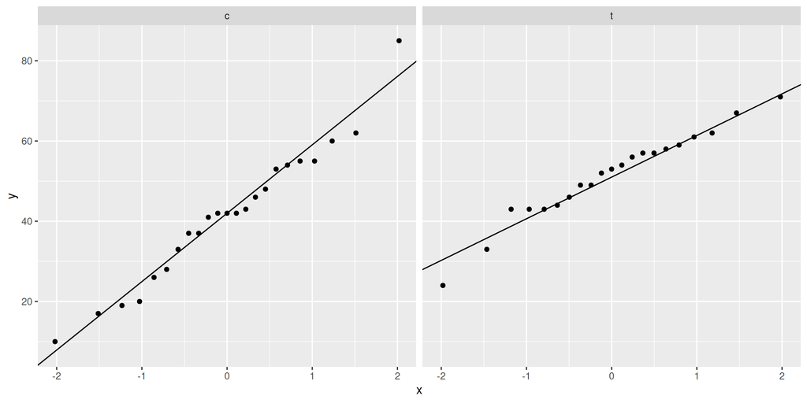

```r
ggplot(kids, aes(sample = score)) + stat_qq() +
  stat_qq_line() + facet_wrap(~ group)
```

## Getting just the control group

- Use `filter` to select rows where something is true:

```r
kids %>% filter(group == "c") -> controls
controls
```

| group | score |
| --- | --- |
| c | 42 |
| c | 33 |
| c | 46 |
| c | 37 |
| c | 43 |
| c | 41 |
| c | 10 |
| c | 42 |
| c | 55 |
| c | 19 |

[output cut: 13 more lines]

## Bootstrap these

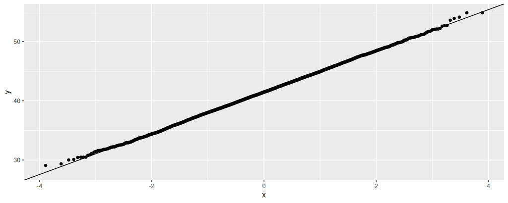

```r
tibble(sim = 1:10000) %>%
  rowwise() %>%
  mutate(sample = list(sample(controls$score, replace = TRUE))) %>%
  mutate(my_mean = mean(sample)) %>%
  ggplot(aes(sample = my_mean)) + stat_qq() + stat_qq_line()
```

## … and the treatment group:

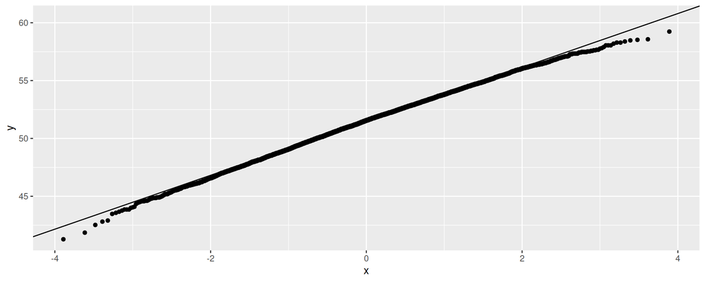

```r
kids %>% filter(group == "t") -> treats
tibble(sim = 1:10000) %>%
  rowwise() %>%
  mutate(sample = list(sample(treats$score, replace = TRUE))) %>%
  mutate(my_mean = mean(sample)) %>%
  ggplot(aes(sample = my_mean)) + stat_qq() + stat_qq_line()
```

## Comments

- sampling distributions of sample means both look pretty normal, though treatment group is a tiny bit left-skewed
- as we thought, no problems with our two-sample $t$ at all.